# Part II - (E-Commerce Super Store Dataset Exploration)

## by (Mahdi Ben Fekih)

## Investigation Overview

> In this investigation, I tried to look into the main variables that affect the profit. The main focus were alloted to profit and sales.

## Dataset Overview

> The dataset selected for this project is a sample from an E-commerce super store sales that operates on a global scale. The dataset is added to the submission folder. Through a detailed, meticulous exploratory analysis and with the help of data visualization, a variety of data trends were uncovered. This jupyter notebook contains different parts, ranging from data wrangling to univariate, bivariate and multivariate data visualization.

## Distribution of Countries and Market Share

#### With 20 countries included and 6 market where operates this online store, The US is the first ranking country ordering and market share wise.

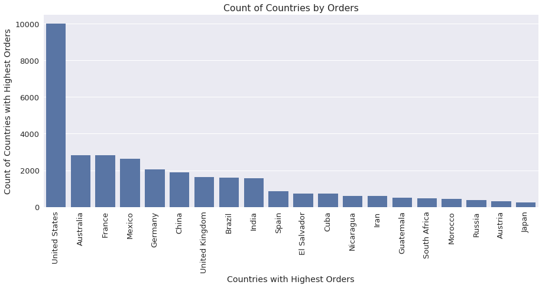

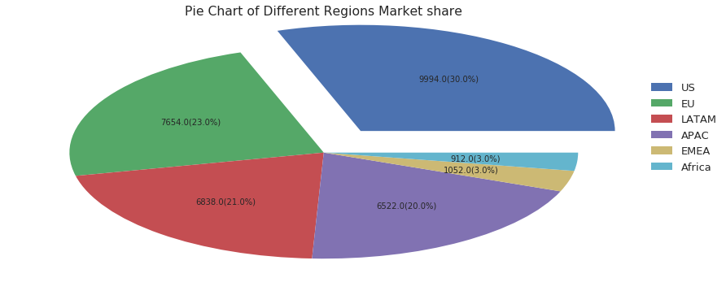

## Most profitable markets and categories

#### It is found that APAC and EU, although do not possess the highest order count, they actually incur more profit than the US. It is also found that Technology category is the most profitable.

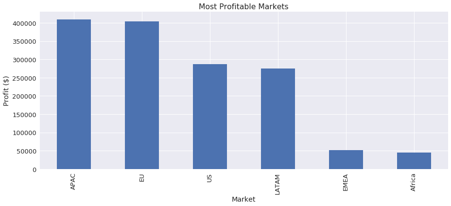

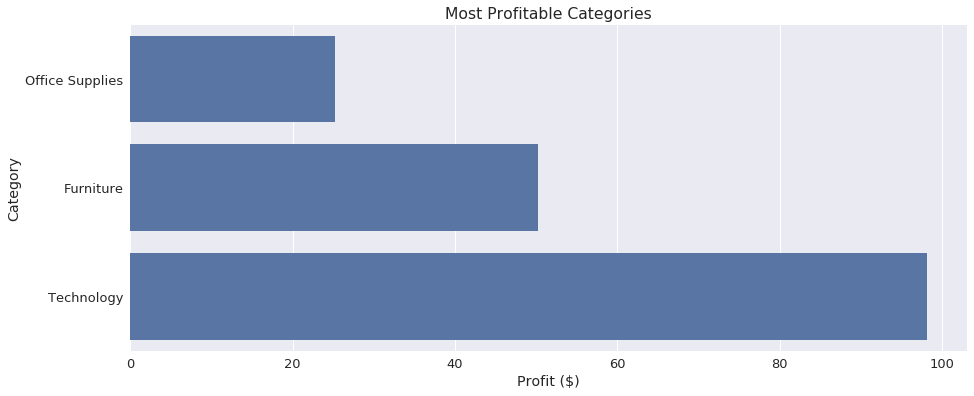

## Correlation heatmap of numeric variables.

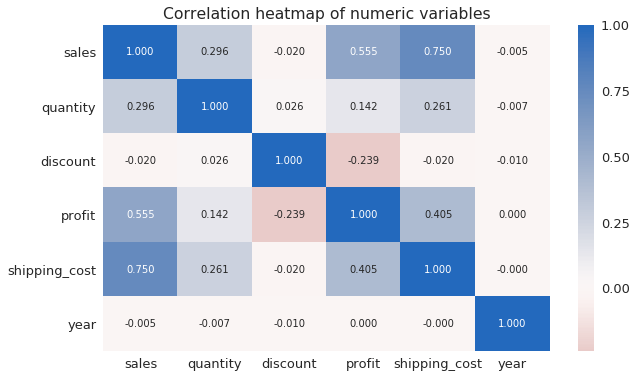

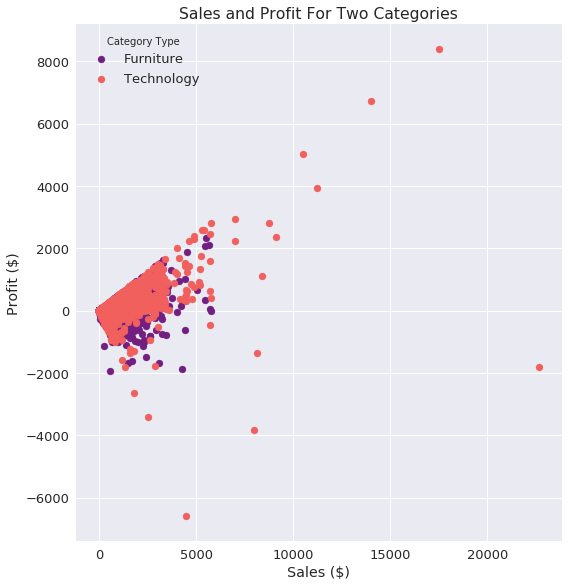

## Revealing the most profitable / most loss incuring items.

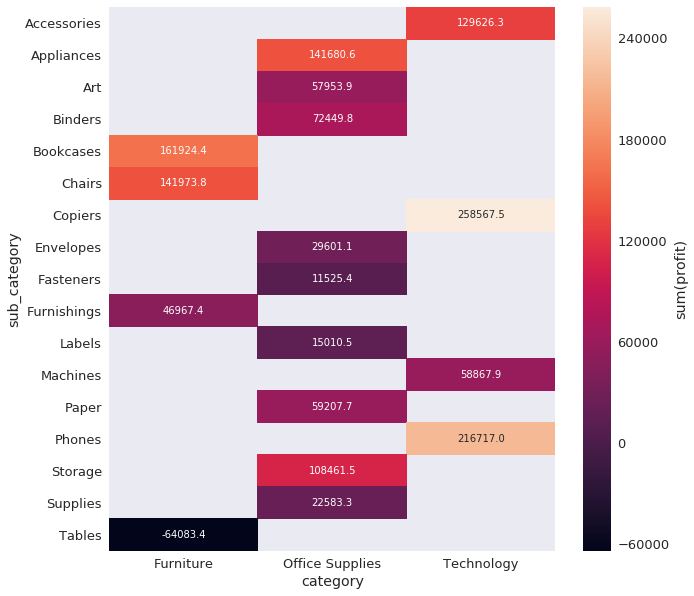